# NYPD Complaint Data: STAT 184 Final Project

Ally Racho

Necessary Libraries:

```r
library(mosaic)
library(tidyverse)
```

Since the original dataset has over 1 million cases and is too large of a file, I will be sampling my data to a smaller set of 250000 cases.

```r
SampleData <-
  sample(NYPD_Complaint_Data_Historic, 250000)
```

### Research Question

Based on the NYC borough and average income per borough, does there seem to be a trend in a certain type of crime committed there?

### Becoming Acquainted with data:

- Where did you find them? – www.data.cityofnewyork.us,www.psc.isr.umich.edu/dis/census/Features/tract2zip/
- Who collected/maintains them? – The dataset for NYPD_Complaint_Data_Historic is provided by the NYPD and maintained/updated by NYC Open Data. The data for MeanZIP is provided and maintained by University of Michigan Population Studies Center.
- When & Why were they originally collected? – The NYPD data was originally collected to engage New Yorkers in information that is produced and collected by the City government. The collection started in 2006, but was made public in 2016 and is updated frequently. The MeanZip was created to explain how to create a zipcode dataset. The data is based on information from 2006-2010. I was unable to see when the data was originally released by the website.
- What does a case represent in each data source, and how many total cases are available? – A case for NYPD represents a crime that occurred on a certain day, time, location. In the original dataset there are 6.5 million cases, but I created a sample subset which contains 250000. A case for MeanZip is based on zipcode, and the avg/median income of such. There are 32634 cases for this dataset.
- What are some of the variables that you plan to use – For the NYPD dataset, I plan to use the BORO_NM (borough crime occurred in), OFNS_DESC (crime description), CMPLNT_FR_DT (exact time of occurence), and LAW_CAT_CD (level of offense, ie. felony, misdemeanor). For MeanZIP, I plan to use Zip (Zip code), Mean (Avg. Income), Pop (Population).

```r
names(SampleData)     ## Names of variables
```

```
 [1] "CMPLNT_NUM"        "CMPLNT_FR_DT"      "CMPLNT_FR_TM"      "CMPLNT_TO_DT"
 [5] "CMPLNT_TO_TM"      "RPT_DT"            "KY_CD"             "OFNS_DESC"
 [9] "PD_CD"             "PD_DESC"           "CRM_ATPT_CPTD_CD"  "LAW_CAT_CD"
[13] "JURIS_DESC"        "BORO_NM"           "ADDR_PCT_CD"       "LOC_OF_OCCUR_DESC"
[17] "PREM_TYP_DESC"     "PARKS_NM"          "HADEVELOPT"        "X_COORD_CD"
[21] "Y_COORD_CD"        "Latitude"          "Longitude"         "Lat_Lon"
[25] "orig.id"
```

```r
nrow(SampleData)       ## Number of Cases
```

```
[1] 250000
```

```r
str(SampleData)       ## Structure of object, information of class
```

```
Classes ‘tbl_df’, ‘tbl’ and 'data.frame':   250000 obs. of  25 variables:
 $ CMPLNT_NUM       : num  7.99e+08 4.91e+08 7.75e+08 4.53e+08 6.49e+08 ...
 $ CMPLNT_FR_DT     : chr  "6/17/2014" "8/23/2015" "11/6/2015" "7/17/2014" ...
 $ CMPLNT_FR_TM     :Classes 'hms', 'difftime'  atomic [1:250000] 1500 10800 43080 79200 79200 ...
  .. ..- attr(*, "units")= chr "secs"
 $ CMPLNT_TO_DT     : chr  "6/17/2014" "8/23/2015" "11/6/2015" NA ...
 $ CMPLNT_TO_TM     :Classes 'hms', 'difftime'  atomic [1:250000] 1800 48600 43200 NA 80040 ...
  .. ..- attr(*, "units")= chr "secs"
 $ RPT_DT           : chr  "6/17/2014" "8/23/2015" "11/6/2015" "7/20/2014" ...
 $ KY_CD            : num  126 121 341 344 344 106 126 232 353 578 ...
 $ OFNS_DESC        : chr  "MISCELLANEOUS PENAL LAW" "CRIMINAL MISCHIEF & RELATED OF" "PETIT LARCENY" "ASSAULT 3 & RELATED OFFENSES" ...
 $ PD_CD            : num  760 267 338 101 113 109 117 490 462 638 ...
 $ PD_DESC          : chr  "BRIBERY,PUBLIC ADMINISTRATION" "MISCHIEF, CRIMINAL 3 & 2, OF M" "LARCENY,PETIT FROM BUILDING,UN" "ASSAULT 3" ...
 $ CRM_ATPT_CPTD_CD : chr  "COMPLETED" "COMPLETED" "COMPLETED" "COMPLETED" ...
 $ LAW_CAT_CD       : chr  "FELONY" "FELONY" "MISDEMEANOR" "MISDEMEANOR" ...
 $ JURIS_DESC       : chr  "N.Y. POLICE DEPT" "N.Y. POLICE DEPT" "N.Y. POLICE DEPT" "N.Y. POLICE DEPT" ...
 $ BORO_NM          : chr  "QUEENS" "BRONX" "BRONX" "BRONX" ...
 $ ADDR_PCT_CD      : num  115 41 40 44 104 122 105 78 25 68 ...
 $ LOC_OF_OCCUR_DESC: chr  "INSIDE" "OPPOSITE OF" "INSIDE" "INSIDE" ...
 $ PREM_TYP_DESC    : chr  "RESIDENCE - APT. HOUSE" "STREET" "PUBLIC SCHOOL" "RESIDENCE - APT. HOUSE" ...
 $ PARKS_NM         : chr  NA NA NA NA ...
 $ HADEVELOPT       : chr  NA NA NA NA ...
 $ X_COORD_CD       : num  1016587 1015287 1009970 1009394 1017194 ...
 $ Y_COORD_CD       : num  213248 235984 234606 242828 199261 ...
 $ Latitude         : num  40.8 40.8 40.8 40.8 40.7 ...
 $ Longitude        : num  -73.9 -73.9 -73.9 -73.9 -73.9 ...
 $ Lat_Lon          : chr  "(40.751942137, -73.883288619)" "(40.814351029, -73.887875625)" "(40.810585884, -73.907089351)" "(40.833154599, -73.909139311)" ...
 $ orig.id          : chr  "748230" "173419" "70073" "701401" ...
```

```r
names(MeanZIP_3)     ## Names of variables
```

```
[1] "Zip"    "Median" "Mean"   "Pop"
```

```r
nrow(MeanZIP_3)       ## Number of Cases
```

```
[1] 32634
```

```r
str(MeanZIP_3)       ## Structure of object, information of class
```

```
Classes ‘tbl_df’, ‘tbl’ and 'data.frame':   32634 obs. of  4 variables:
 $ Zip   : num  1001 1002 1003 1005 1007 ...
 $ Median: num  56663 49853 28462 75423 79076 ...
 $ Mean  : num  66688 75063 35121 82442 85802 ...
 $ Pop   : num  16445 28069 8491 4798 12962 ...
```

## Exploring intuition related to the research question

### Create some informative plots and summary statistics

1. Level of crime faceted among the boroughs (NYPD)

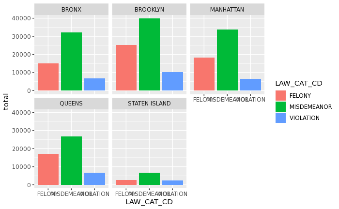

```r
FelonyMisdCrimeBasedonBorough <-
  SampleData %>%
  group_by(BORO_NM,LAW_CAT_CD) %>%
  summarize(total = sum(n()))
FelonyMisdCrimeBasedonBorough %>%
  ggplot(aes(x = LAW_CAT_CD, y = total, fill = LAW_CAT_CD))+
  geom_bar(stat= 'identity', position = 'dodge', width = .9)+
  facet_wrap(~ BORO_NM, ncol=3)
```

2. Most popular crime based on borough (NYPD)

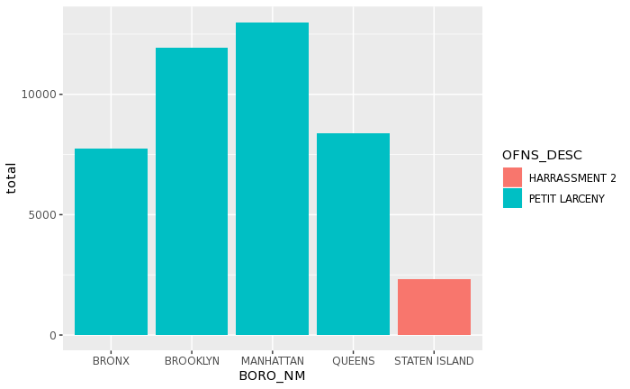

```r
PopularBoroughCrime <-
  SampleData %>%
  group_by(BORO_NM, OFNS_DESC) %>%
  summarise(total = sum(n())) %>%
  filter(total == max(total))
PopularBoroughCrime %>%
  ggplot(aes(x = BORO_NM, y = total, fill = OFNS_DESC))+
  geom_bar(stat= 'identity', position = 'dodge', width = .9)
```

3. Based on zip code of borough, what is the mean family income? (MeanZip_3)

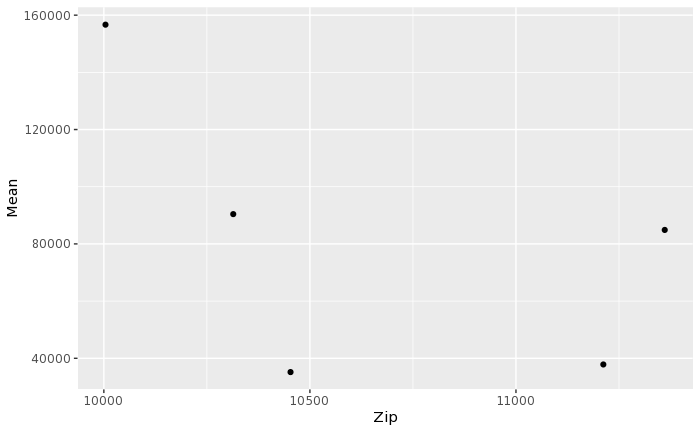

```r
MedianIncome <-
  MeanZIP_3 %>%
  filter(Zip == 10453 | Zip == 11212 | Zip == 10004 | Zip == 11361 | Zip == 10314) %>%
  ggplot(aes(x = Zip, y =Mean))+
  geom_point()
MedianIncome
```

### Two Data Sources

- Primary data: NYPD_Complaint_Data_Historic — SampleData
- Other data sources: MeanZIP-3